# Wine Sales

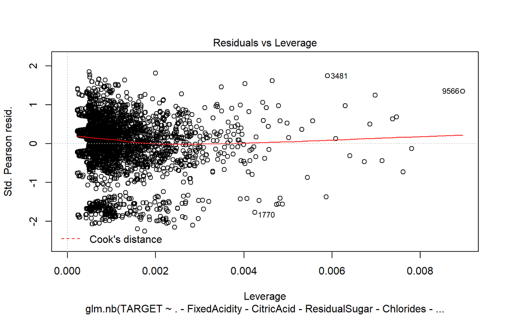

Removing non significant variables doesn’t seem to affect the model’s accuracy much. ### Model 7 : Negative Binomial Model with imputations

```
##
## Call:
## glm.nb(formula = TARGET ~ ., data = wine_train2, init.theta = 49067.84702,
##     link = log)
##
## Deviance Residuals:
##     Min       1Q   Median       3Q      Max
## -2.9896  -0.6852   0.1295   0.6351   2.4377
##
## Coefficients:
##                      Estimate Std. Error z value Pr(>|z|)
## (Intercept)         2.350e+00  2.280e-01  10.307  < 2e-16 ***
## FixedAcidity        2.238e-04  9.202e-04   0.243 0.807848
## VolatileAcidity    -4.578e-02  7.287e-03  -6.282 3.34e-10 ***
## CitricAcid          6.770e-03  6.566e-03   1.031 0.302510
## ResidualSugar       1.586e-04  1.674e-04   0.947 0.343463
## Chlorides          -6.268e-02  1.794e-02  -3.494 0.000476 ***
## FreeSulfurDioxide   1.249e-04  3.801e-05   3.285 0.001020 **
## TotalSulfurDioxide  8.362e-05  2.457e-05   3.403 0.000666 ***
## Density            -3.887e-01  2.145e-01  -1.813 0.069902 .
## pH                 -1.990e-02  8.406e-03  -2.367 0.017923 *
## Sulphates          -1.035e-02  6.173e-03  -1.677 0.093603 .
## Alcohol             2.527e-03  1.557e-03   1.623 0.104549
## LabelAppeal         1.429e-01  6.779e-03  21.084  < 2e-16 ***
## AcidIndex          -7.543e-01  4.005e-02 -18.832  < 2e-16 ***
## STARS               3.433e-01  6.241e-03  54.998  < 2e-16 ***
## ---
## Signif. codes:  0 '***' 0.001 '**' 0.01 '*' 0.05 '.' 0.1 ' ' 1
##
## (Dispersion parameter for Negative Binomial(49067.85) family taken to be 1)
##
##     Null deviance: 18290  on 10236  degrees of freedom
## Residual deviance: 12766  on 10222  degrees of freedom
## AIC: 38357
##
## Number of Fisher Scoring iterations: 1
##
##
##               Theta:  49068
##           Std. Err.:  63120
## Warning while fitting theta: iteration limit reached
##
##  2 x log-likelihood:  -38324.77
```

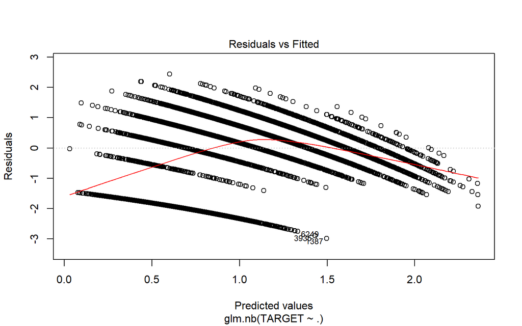

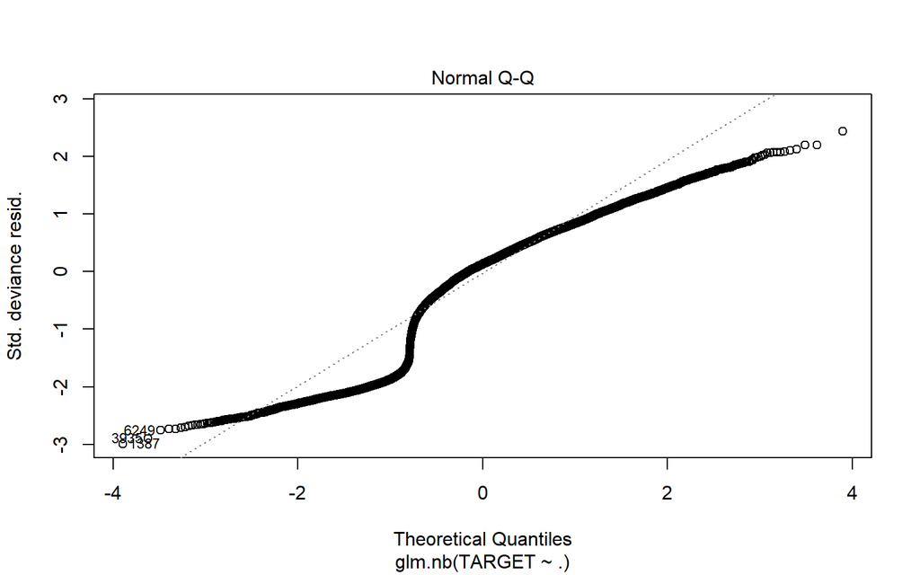

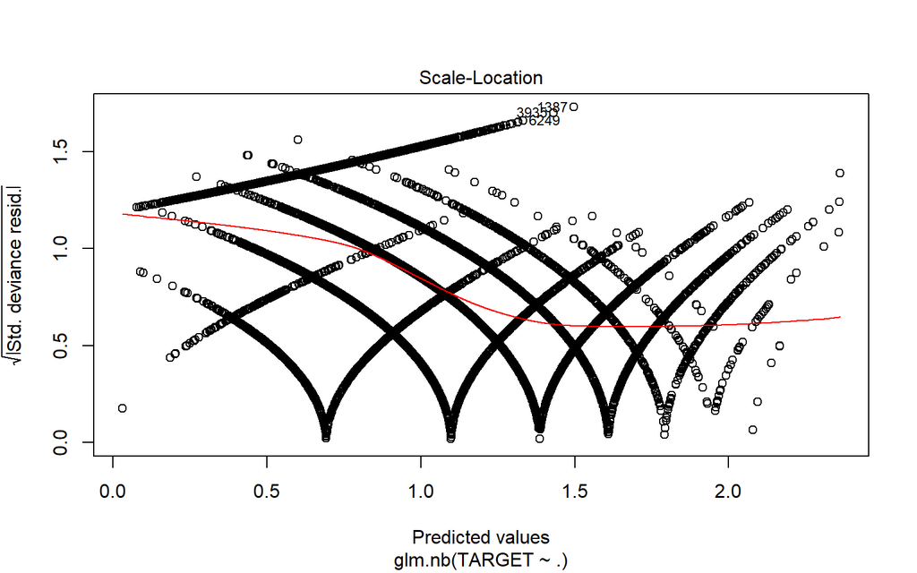

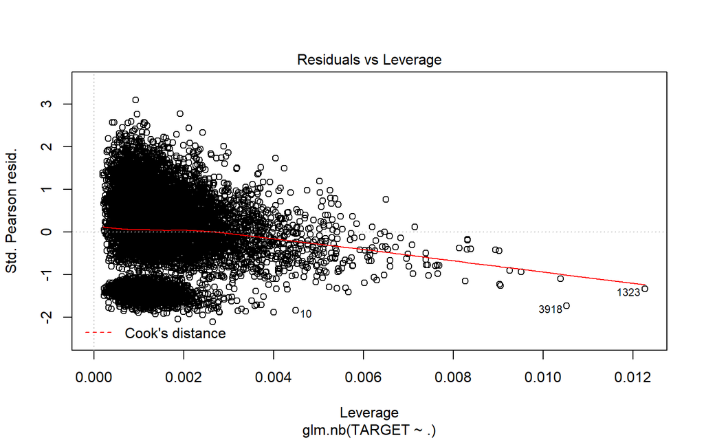

With imputations we find surprisingly similar results to a the Poisson model with imputations. ### Model 8 : Negative Binomial Model with imputations and only significant variables

|  | Estimate | Std. Error | z value | Pr(>\|z\|) |
| --- | --- | --- | --- | --- |
| **(Intercept)** | 2.001 | 0.0885 | 22.61 | 3.826e-113 |
| **VolatileAcidity** | -0.04605 | 0.007285 | -6.321 | 2.592e-10 |
| **Chlorides** | -0.06452 | 0.01793 | -3.599 | 0.0003195 |
| **FreeSulfurDioxide** | 0.0001233 | 3.8e-05 | 3.245 | 0.001173 |
| **TotalSulfurDioxide** | 8.234e-05 | 2.454e-05 | 3.355 | 0.0007937 |
| **pH** | -0.02022 | 0.008403 | -2.406 | 0.01613 |
| **Sulphates** | -0.01025 | 0.006167 | -1.661 | 0.09662 |
| **LabelAppeal** | 0.1429 | 0.006779 | 21.08 | 1.257e-98 |
| **AcidIndex** | -0.7573 | 0.03941 | -19.22 | 2.622e-82 |
| **STARS** | 0.3442 | 0.006224 | 55.3 | 0 |

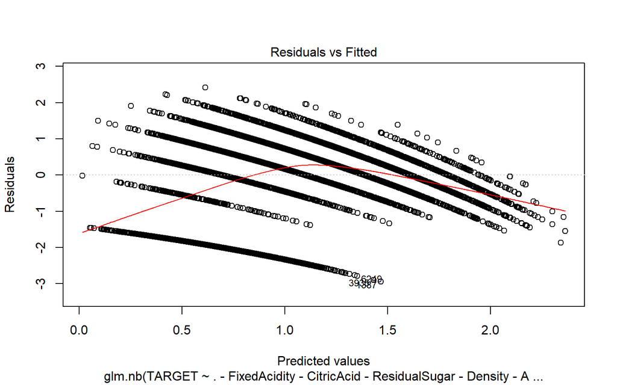

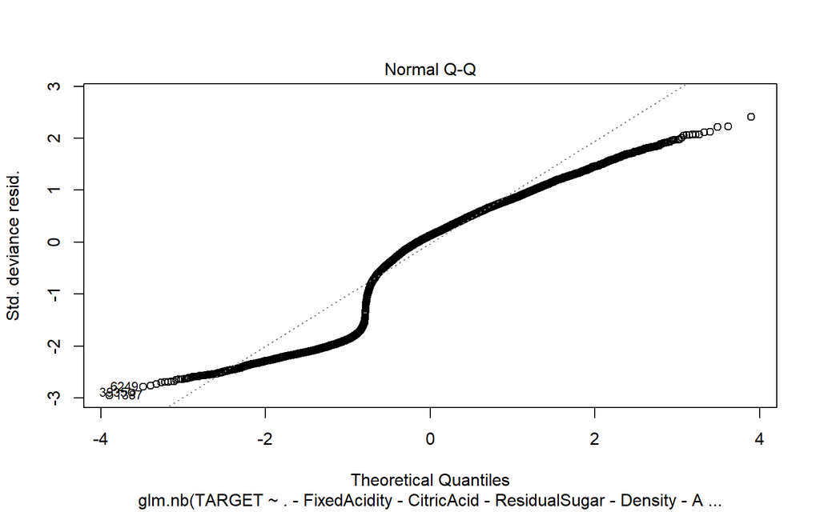

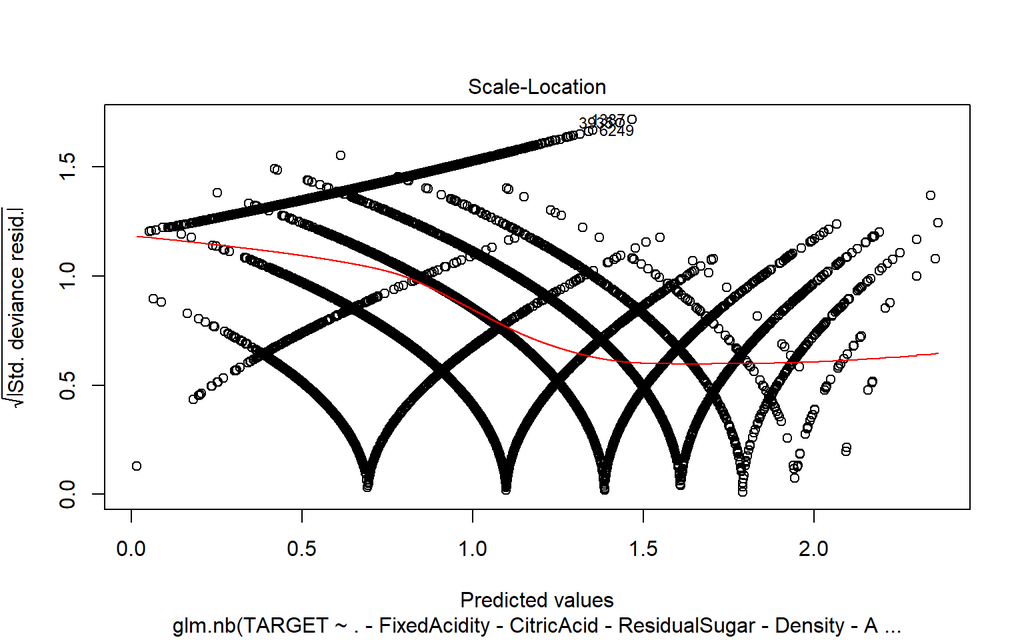

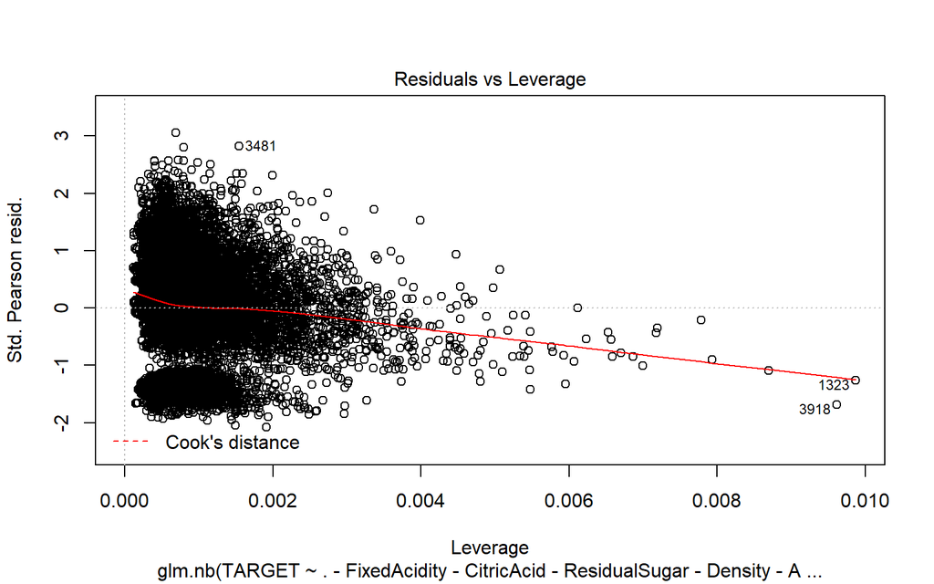

## Model III: Linear Model

### Model 9 : Linear Model with imputations

Use imputed training data on Linear regression model

|  | Estimate | Std. Error | t value | Pr(>\|t\|) |
| --- | --- | --- | --- | --- |
| **(Intercept)** | 6.001 | 0.5535 | 10.84 | 3.054e-27 |
| **FixedAcidity** | 0.001363 | 0.002241 | 0.6083 | 0.543 |
| **VolatileAcidity** | -0.1326 | 0.01781 | -7.445 | 1.049e-13 |
| **CitricAcid** | 0.0195 | 0.01621 | 1.203 | 0.2291 |
| **ResidualSugar** | 0.0004527 | 0.0004108 | 1.102 | 0.2704 |
| **Chlorides** | -0.1916 | 0.04383 | -4.371 | 1.248e-05 |
| **FreeSulfurDioxide** | 0.0003229 | 9.354e-05 | 3.452 | 0.0005596 |
| **TotalSulfurDioxide** | 0.0002237 | 5.984e-05 | 3.738 | 0.0001868 |
| **Density** | -0.9958 | 0.5233 | -1.903 | 0.05705 |
| **pH** | -0.04893 | 0.0206 | -2.376 | 0.01754 |
| **Sulphates** | -0.02701 | 0.0151 | -1.789 | 0.07369 |
| **Alcohol** | 0.01092 | 0.003777 | 2.892 | 0.003831 |
| **LabelAppeal** | 0.4385 | 0.01633 | 26.86 | 1.213e-153 |
| **AcidIndex** | -2.02 | 0.09201 | -21.95 | 1.996e-104 |
| **STARS** | 1.175 | 0.01655 | 71.03 | 0 |

Fitting linear model: TARGET ~ .

| Observations | Residual Std. Error | $R^2$ | Adjusted $R^2$ |
| --- | --- | --- | --- |
| 10237 | 1.409 | 0.4661 | 0.4654 |

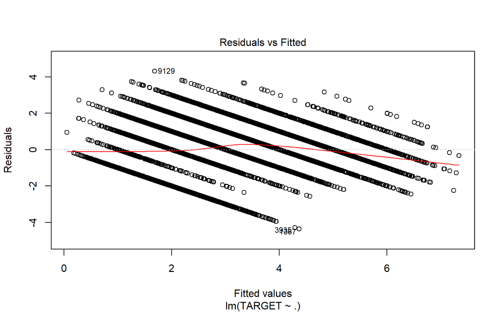

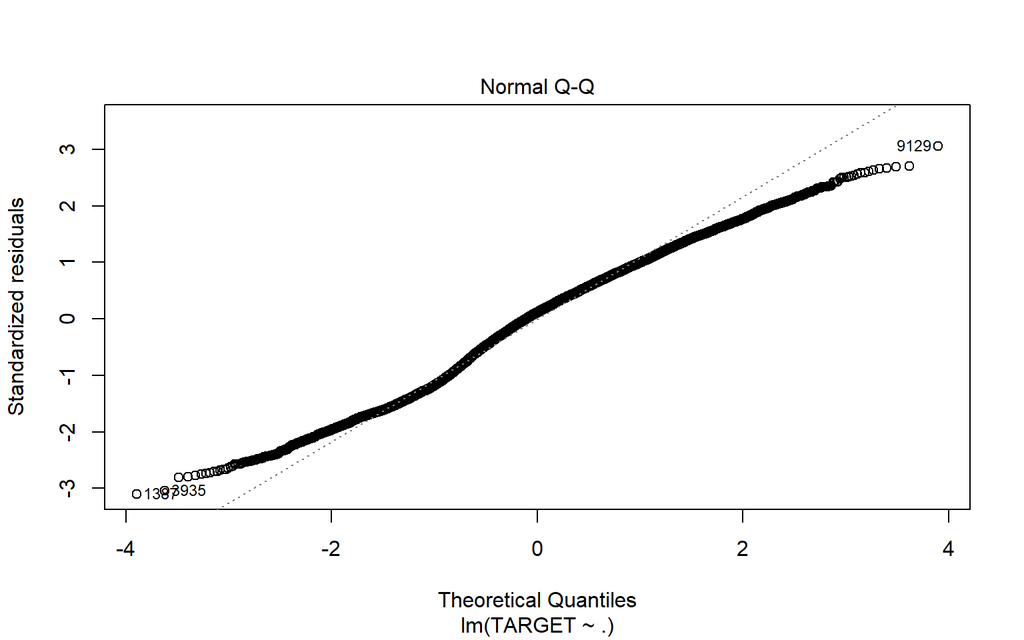

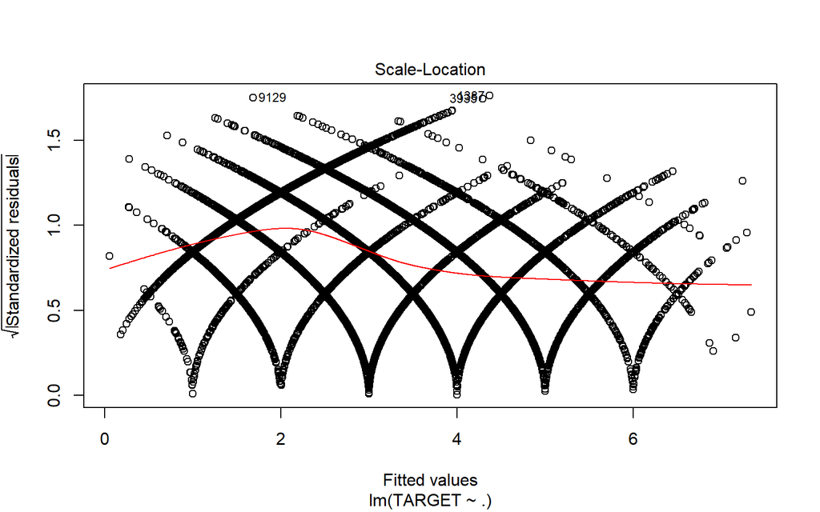

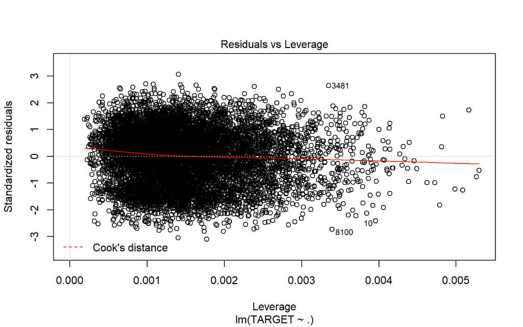

A plain linear regression model is a surprisingly decent performer when coupled with imputations. ### Model 10 : Linear Model with imputations and only significant variables.

|  | Estimate | Std. Error | t value | Pr(>\|t\|) |
| --- | --- | --- | --- | --- |
| **(Intercept)** | 5.986 | 0.5534 | 10.82 | 3.965e-27 |
| **VolatileAcidity** | -0.1333 | 0.01781 | -7.485 | 7.738e-14 |
| **Chlorides** | -0.1928 | 0.04382 | -4.4 | 1.095e-05 |
| **FreeSulfurDioxide** | 0.0003249 | 9.353e-05 | 3.474 | 0.0005151 |
| **TotalSulfurDioxide** | 0.0002256 | 5.981e-05 | 3.771 | 0.0001632 |
| **Density** | -0.9991 | 0.5232 | -1.909 | 0.05623 |
| **pH** | -0.04897 | 0.02059 | -2.378 | 0.01743 |
| **Sulphates** | -0.02735 | 0.01509 | -1.813 | 0.06993 |
| **Alcohol** | 0.01087 | 0.003775 | 2.879 | 0.003998 |
| **LabelAppeal** | 0.4384 | 0.01633 | 26.85 | 1.518e-153 |
| **AcidIndex** | -2.002 | 0.09039 | -22.15 | 3.248e-106 |
| **STARS** | 1.176 | 0.01654 | 71.08 | 0 |

Fitting linear model: TARGET ~ . - FixedAcidity - CitricAcid - ResidualSugar

| Observations | Residual Std. Error | $R^2$ | Adjusted $R^2$ |
| --- | --- | --- | --- |
| 10237 | 1.409 | 0.466 | 0.4654 |

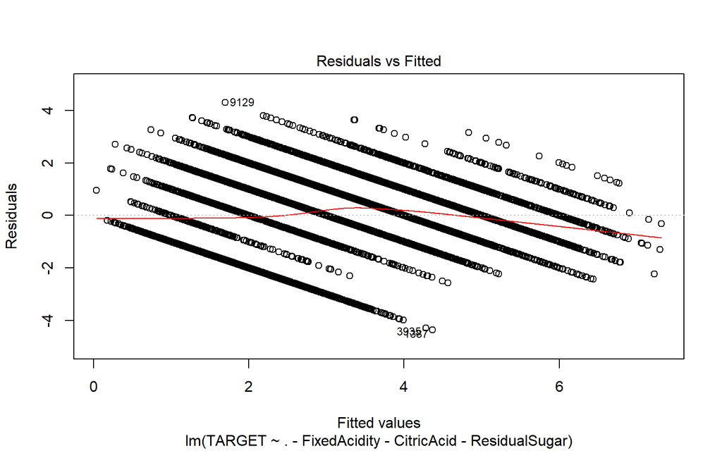

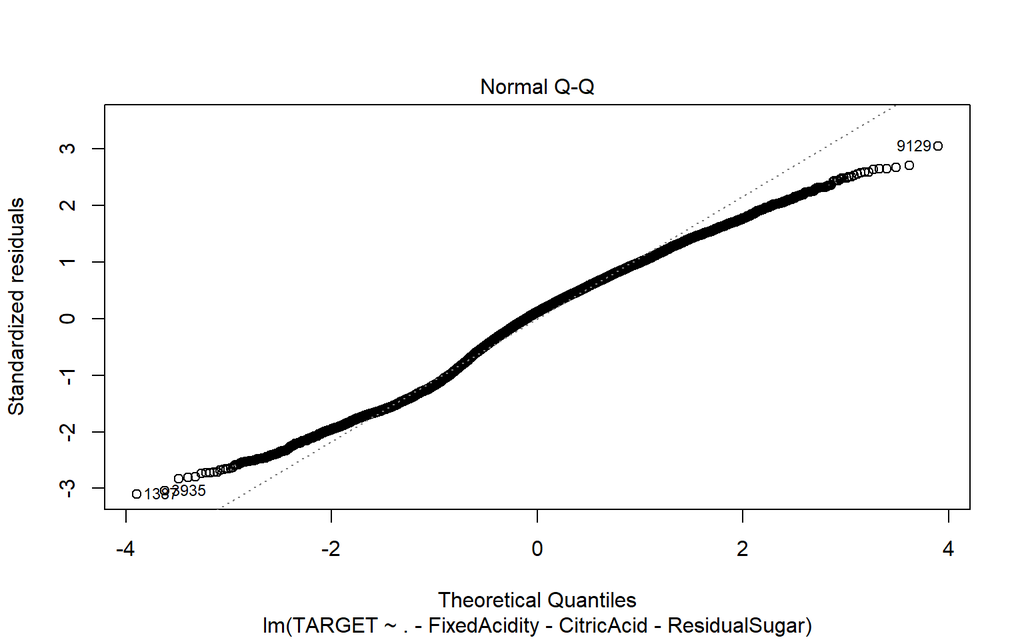

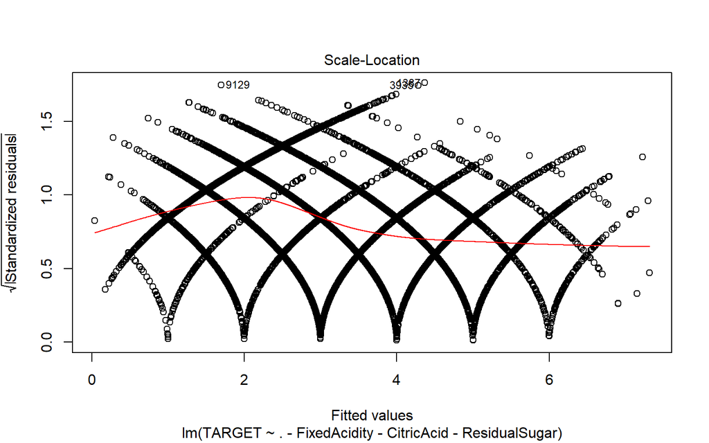

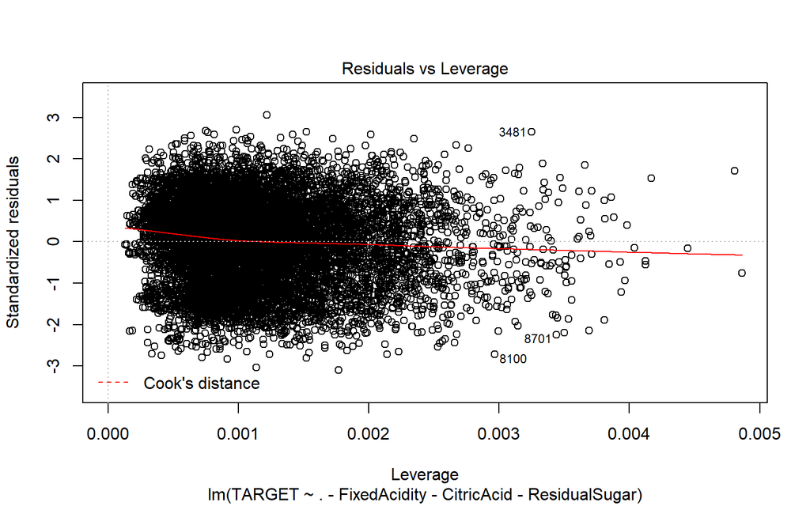

Again, removing less significant variables has little impact on the model, and is recommended to reduce overfitting. ## Model 11 : Ordinal Logistic Regression

Since Ordinal logistic regression uses ordered factors we might find this as one of the top model based on our use cases.

Call: polr(formula = TARGET ~ ., data = polrDF, Hess = TRUE)

Coeficients

|  | Value | Std. Error | t value |
| --- | --- | --- | --- |
| **FixedAcidity** | 0.002554 | 0.002909 | 0.878 |
| **VolatileAcidity** | -0.1636 | 0.02328 | -7.026 |
| **CitricAcid** | 0.01951 | 0.02111 | 0.9242 |
| **ResidualSugar** | 0.0003666 | 0.000531 | 0.6904 |
| **Chlorides** | -0.2396 | 0.05681 | -4.217 |
| **FreeSulfurDioxide** | 0.0004071 | 0.0001216 | 3.347 |
| **TotalSulfurDioxide** | 0.0002398 | 7.814e-05 | 3.068 |
| **Density** | -1.514 | 0.1493 | -10.14 |
| **pH** | -0.0386 | 0.02685 | -1.438 |
| **Sulphates** | -0.02078 | 0.01982 | -1.048 |
| **Alcohol** | 0.02535 | 0.004883 | 5.19 |
| **LabelAppeal** | 0.833 | 0.02381 | 34.98 |
| **AcidIndex** | -2.598 | 0.1251 | -20.77 |
| **STARS** | 1.473 | 0.02563 | 57.48 |

Intercepts

|  | Value | Std. Error | t value |
| --- | --- | --- | --- |
| **0\|1** | -6.027 | 0.136 | -44.31 |
| **1\|2** | -5.89 | 0.1359 | -43.34 |
| **2\|3** | -5.283 | 0.1355 | -38.99 |
| **3\|4** | -3.912 | 0.1354 | -28.89 |
| **4\|5** | -2.064 | 0.1377 | -14.99 |
| **5\|6** | -0.09522 | 0.1442 | -0.6605 |
| **6\|7** | 2.103 | 0.1679 | 12.53 |
| **7\|8** | 4.44 | 0.3036 | 14.62 |

Residual Deviance: 29978.30

AIC: 30022.30

## Model 12 : Zero inflation

```
##
## Call:
## zeroinfl(formula = TARGET ~ . | STARS, data = wine_train2, dist = "negbin")
##
## Pearson residuals:
##      Min       1Q   Median       3Q      Max
## -2.17822 -0.50776  0.06056  0.48757  2.09505
##
## Count model coefficients (negbin with log link):
##                      Estimate Std. Error z value Pr(>|z|)
## (Intercept)         1.793e+00  2.380e-01   7.532 4.99e-14 ***
## FixedAcidity        5.166e-04  9.446e-04   0.547  0.58447
## VolatileAcidity    -2.095e-02  7.556e-03  -2.772  0.00556 **
## CitricAcid          7.361e-04  6.706e-03   0.110  0.91260
## ResidualSugar      -3.494e-05  1.721e-04  -0.203  0.83913
## Chlorides          -2.832e-02  1.851e-02  -1.530  0.12608
## FreeSulfurDioxide   3.380e-05  3.849e-05   0.878  0.37983
## TotalSulfurDioxide  4.004e-07  2.457e-05   0.016  0.98700
## Density            -2.918e-01  2.222e-01  -1.313  0.18915
## pH                  8.443e-04  8.732e-03   0.097  0.92297
## Sulphates          -2.372e-03  6.392e-03  -0.371  0.71058
## Alcohol             6.463e-03  1.587e-03   4.073 4.63e-05 ***
## LabelAppeal         2.280e-01  7.088e-03  32.169  < 2e-16 ***
## AcidIndex          -2.614e-01  4.464e-02  -5.856 4.73e-09 ***
## STARS               1.200e-01  6.995e-03  17.156  < 2e-16 ***
## Log(theta)          1.749e+01  4.449e+00   3.932 8.44e-05 ***
##
## Zero-inflation model coefficients (binomial with logit link):
##             Estimate Std. Error z value Pr(>|z|)
## (Intercept)   2.7093     0.1347   20.11   <2e-16 ***
## STARS        -3.0279     0.1235  -24.51   <2e-16 ***
## ---
## Signif. codes:  0 '***' 0.001 '**' 0.01 '*' 0.05 '.' 0.1 ' ' 1
##
## Theta = 39544917.0696
## Number of iterations in BFGS optimization: 23
## Log-likelihood: -1.715e+04 on 18 Df
```

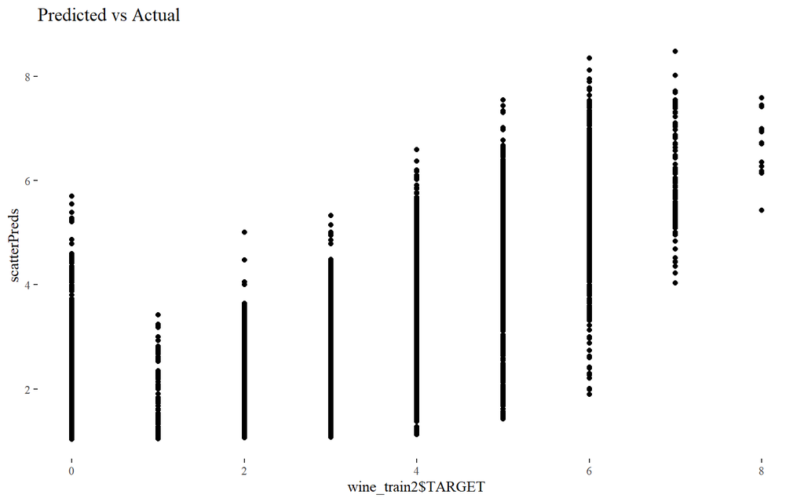

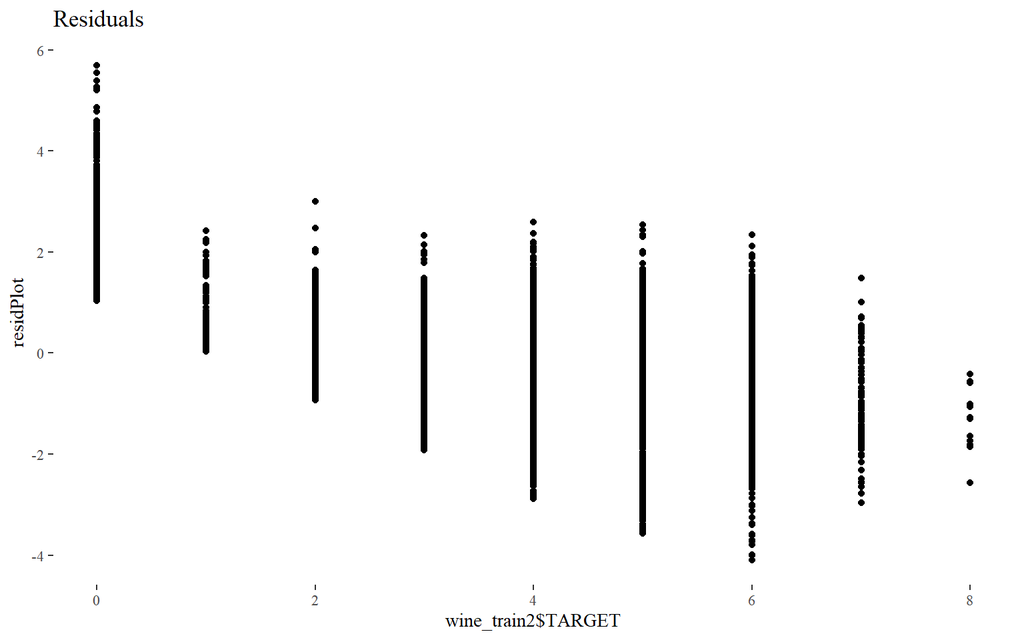

Interestingly Sulfur Dioxides and Sulphates are not significant in this model, while Alcohol is. # SELECT MODELS

## Compare Models based on MSE/AIC

[output not shown]

Similar MSE values are observed for Poisson and negative binomial models.

We can compare our zero inflated model using a Vuong test to a normal Poisson model.

```r
vuong(model4,model12)
```

```
## Vuong Non-Nested Hypothesis Test-Statistic:
## (test-statistic is asymptotically distributed N(0,1) under the
##  null that the models are indistinguishible)
## -------------------------------------------------------------
##               Vuong z-statistic             H_A    p-value
## Raw                   -35.18951 model2 > model1 < 2.22e-16
## AIC-corrected         -35.06714 model2 > model1 < 2.22e-16
## BIC-corrected         -34.62454 model2 > model1 < 2.22e-16
```

Model2, or our Zero Inflated model, would seem to be better than our non inflated model.

## Compare Models by Loss

Use test data and check the output

In order to validate we will use squared loss and squared difference to select model (MSE) from predicting on selected training datasets. Smaller numbers would indicate a truer fit.

```
##            Loss:
## Model1  5.479565
## Model2  5.464097
## Model3  6.844632
## Model4  6.845511
## Model5  5.479559
## Model6  5.464091
## Model7  6.844628
## Model8  6.845507
## Model9  2.038659
## Model10 2.037739
## Model11 3.667318
## Model12 2.003325
```

Based on above results these are our observation

-> Linear model performed well. -> Poisson regression model and Negative binomial model did not performed as expected. -> We expected Ordinal logistic regression to be a better model but it did not performed well.

At this point we are concentrated more on square loss which tells us the accuracy of our model

## Prediction on Evaluation Data

Here we use MICE just like how we used earlier for imputing and log transformation for AcidIndex.

Display the Predicted values

Table continues below

| TARGET | FixedAcidity | VolatileAcidity | CitricAcid | ResidualSugar |
| --- | --- | --- | --- | --- |
| 1.623 | 5.4 | -0.86 | 0.27 | -10.7 |
| 3.702 | 12.4 | 0.385 | -0.76 | -19.7 |
| 1.719 | 7.2 | 1.75 | 0.17 | -33 |
| 1.484 | 6.2 | 0.1 | 1.8 | 1 |
| 1.65 | 11.4 | 0.21 | 0.28 | 1.2 |
| 5.698 | 17.6 | 0.04 | -1.15 | 1.4 |

Table continues below

| Chlorides | FreeSulfurDioxide | TotalSulfurDioxide | Density | pH |
| --- | --- | --- | --- | --- |
| 0.092 | 23 | 398 | 0.9853 | 5.02 |
| 1.169 | -37 | 68 | 0.9905 | 3.37 |
| 0.065 | 9 | 76 | 1.046 | 4.61 |
| -0.179 | 104 | 89 | 0.9888 | 3.2 |
| 0.038 | 70 | 53 | 1.029 | 2.54 |
| 0.535 | -250 | 140 | 0.9503 | 3.06 |

| Sulphates | Alcohol | LabelAppeal | AcidIndex | STARS |
| --- | --- | --- | --- | --- |
| 0.64 | 12.3 | -1 | 1.792 | 1 |
| 1.09 | 16 | 0 | 1.792 | 2 |
| 0.68 | 8.55 | 0 | 2.079 | 1 |
| 2.11 | 12.3 | -1 | 2.079 | 1 |
| -0.07 | 4.8 | 0 | 2.303 | 1 |
| -0.02 | 11.4 | 1 | 2.079 | 4 |

For TARGET: Number of Cases Purchased as Predicted

```
##    Min. 1st Qu.  Median    Mean 3rd Qu.    Max.    StdD    Skew    Kurt
##    1.01    1.91    3.32    3.25    4.20    8.28    1.38    0.47   -0.36
```

### Predicted Evaluation data

https://github.com/ShovanBiswas/DATA621/blob/master/Homework05/Evaluation_Full_Data.csv

# Appendix

https://github.com/ShovanBiswas/DATA621/blob/master/Homework05/Data621_Hw5.Rmd

Marker: 621-05_p